# Vertical reflection: $y=-f(x)$

- Vertical reflection (reflection over the $x$ axis)
- Let corresponding points $(x_1,y_1)$ and $(x_2,y_2)$ exist such that $y_1=f(x_1)$ if and only if $y_2=-f(x_2)$.
  - Then we know $x_2=x_1$ and $y_2=-y_1$. (Negate the $y$ values.)
  - In other words: $(a,b) \to (a,-b)$ for any point $(a,b)$ on curve $y=f(x)$.
  - For example, $(3,1)$ is on $y=f(x)$ if and only if $(3,-1)$ is on $y=-f(x)$

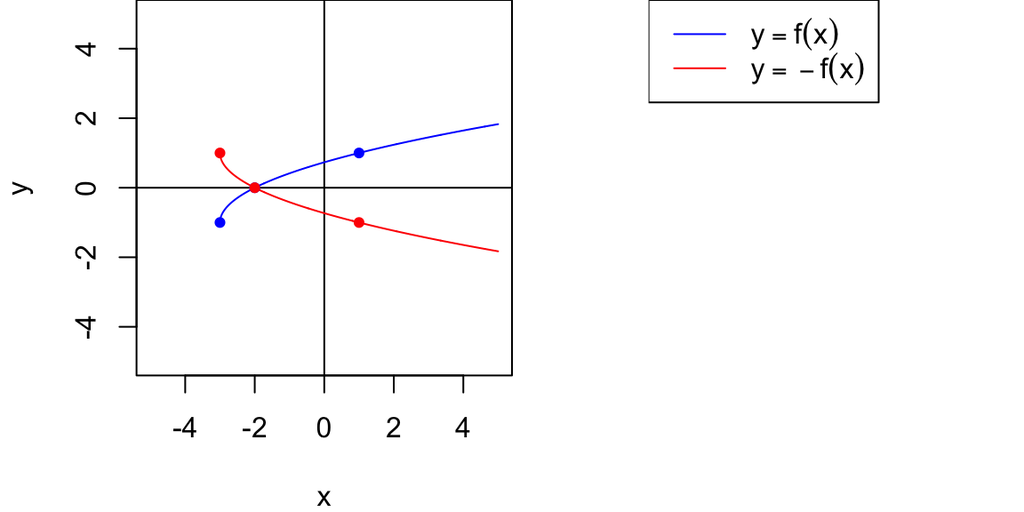

# Horizontal reflection: $y=f(-x)$

- Horizontal reflection (reflection over the $y$ axis)
- Let corresponding points $(x_1,y_1)$ and $(x_2,y_2)$ exist such that $y_1=f(x_1)$ if and only if $y_2=f(-x_2)$.
  - Then we know $x_2=-x_1$ and $y_2=y_1$. (Negate the $x$ values.)
  - In other words: $(a,b) \to (-a,b)$ for any point $(a,b)$ on curve $y=f(x)$.
  - For example, $(3,1)$ is on $y=f(x)$ if and only if $(-3,1)$ is on $y=f(-x)$

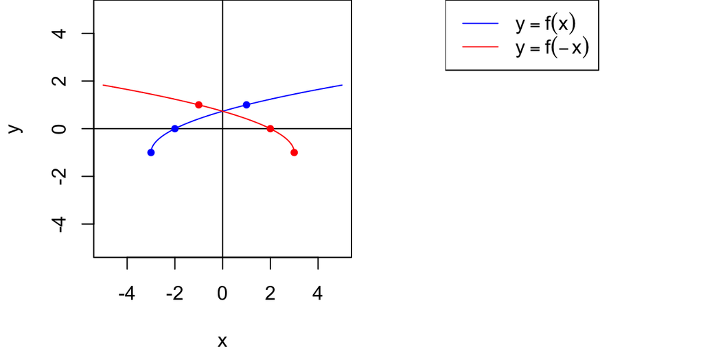

# Inverse function: $y=f^{-1}(x)$

- Reflection over the $y=x$ line.
- Let $f$ represent a one-to-one function.
- Let corresponding points $(x_1,y_1)$ and $(x_2,y_2)$ exist such that $y_1=f(x_1)$ if and only if $y_2=f^{-1}(x_2)$.
  - Then we know $x_2=y_1$ and $y_2=x_1$. (Swap the $x$ and $y$.)
  - In other words: $(a,b) \to (b,a)$ for any point $(a,b)$ on curve $y=f(x)$.
  - For example, $(3,1)$ is on $y=f(x)$ if and only if $(1,3)$ is on $y=f^{-1}(x)$

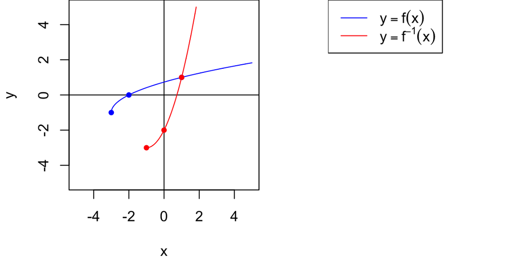

# Double reflection: $y=-f(-x)$

- Double reflection over $x$ axis and then $y$ axis (or 180° rotation around origin).
- Let corresponding points $(x_1,y_1)$ and $(x_2,y_2)$ exist such that $y_1=f(x_1)$ if and only if $y_2=-f(-x_2)$.
  - Then we know $x_2=-x_1$ and $y_2=-y_1$. (Negate the $x$ and $y$ values.)
  - In other words: $(a,b) \to (-a,-b)$ for any point $(a,b)$ on curve $y=f(x)$.
  - For example, $(3,1)$ is on $y=f(x)$ if and only if $(-3,-1)$ is on $y=-f(-x)$

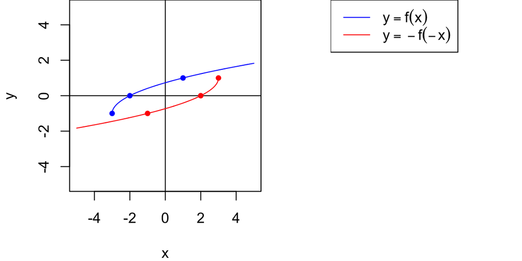